# Investigation of Promoter Window Size on Genomic DBP Activity

William Francis, Eric Young, Eugene Miller, Nickles Badger

Next we imported the Gencode and consensus peak data that we generated in the class 11 RMD.

```r
# Code from class 20 RMD
gencode_gr <- rtracklayer::import("/scratch/Shares/rinnclass/CLASS_2022/data/genomes/gencode.v32.annotation.gtf")
# Loading in files via listing and rtracklayer import
consensus_fl <- list.files("/scratch/Shares/rinnclass/CLASS_2022/EM/CLASS_2022/class_exeRcises/Analysis/11_r_functions/consensus_peaks", full.names = T)
# importing (takes ~5min)
consensus_peaks <- lapply(consensus_fl, rtracklayer::import)
# cleaning up file names
names(consensus_peaks) <- gsub("/scratch/Shares/rinnclass/CLASS_2022/EM/CLASS_2022/class_exeRcises/Analysis/11_r_functions/consensus_peaks/|_consensus_peaks.bed","", consensus_fl)
# Filtering consensus peaks to those DBPs with at least 250 peaks
num_peaks_threshold <- 250
num_peaks <- sapply(consensus_peaks, length)
filtered_consensus_peaks <- consensus_peaks[num_peaks > num_peaks_threshold]
# Result: these were the DBPs that were filtered out.
filtered_dbps <- consensus_peaks[num_peaks < num_peaks_threshold]
names(filtered_dbps)
```

```
##  [1] "CEBPZ"    "GPBP1L1"  "H3K27me3" "HMGA1"    "IRF3"     "MLLT10"
##  [7] "MYBL2"    "NCOA5"    "RNF219"   "RORA"     "ZBTB3"    "ZFP36"
## [13] "ZFP62"    "ZMAT5"    "ZNF10"    "ZNF17"    "ZNF260"   "ZNF382"
## [19] "ZNF48"    "ZNF484"   "ZNF577"   "ZNF597"   "ZNF7"
```

```r
# We have this many remaining DBPs
length(filtered_consensus_peaks)
```

```
## [1] 460
```

We checked the names of dbps and the number of consensus peaks to ensure that the data had been imported correctly.

First, we looked at both biotypes (mRNA, lncRNA) using the “counts” method of count_peaks_per_feature. This method counts each and every binding event to a promoter window such that if the same protein binds multiple times, each binding event is added to the total. This method does not allow for the differentiation of number of unique DBPs that bound inside the promoter window.

```r
numbers = seq(0,5000, by = 250)

# Create matrixes to store the data
mrna_ngenes <- 19965
mrna_mat = matrix(numeric(), ncol = 1000, nrow = length(numbers))

lncrna_ngenes <- 16849
lncrna_mat = matrix(numeric(), ncol = 1000, nrow = length(numbers))

# subset promoters to save loop time (size 1000 random sample)
gene_samples_lncRNA <- gencode_gr[gencode_gr$type == "gene"]
gene_samples_lncRNA <- gene_samples_lncRNA[gene_samples_lncRNA$gene_type %in% "lncRNA"]
gene_samples_lncRNA <- gene_samples_lncRNA[sample(1:length(gene_samples_lncRNA), 1000)]

gene_samples_mRNA <- gencode_gr[gencode_gr$type == "gene"]
gene_samples_mRNA <- gene_samples_mRNA[gene_samples_mRNA$gene_type %in% "protein_coding"]
gene_samples_mRNA <- gene_samples_mRNA[sample(1:length(gene_samples_mRNA), 1000)]

for (i in 1:length(numbers)){ # loop over all window sizes

  # get the regions for each biotype.
  lncrna_promoters <- get_promoter_regions(gene_samples_lncRNA, biotype = "lncRNA",
                                           upstream = numbers[i]/2, downstream = numbers[i]/2)
  mrna_promoters <- get_promoter_regions(gene_samples_mRNA, biotype = "protein_coding",
                                           upstream = numbers[i]/2, downstream = numbers[i]/2)

  # get gene names and count the number of peaks
  names(mrna_promoters) <- mrna_promoters$gene_id
  mrna_promoter_peak_counts <- count_peaks_per_feature(mrna_promoters, filtered_consensus_peaks, type = "counts")

  names(lncrna_promoters) <- lncrna_promoters$gene_id
  lncrna_promoter_peak_counts <- count_peaks_per_feature(lncrna_promoters, filtered_consensus_peaks, type = "counts")

  # save to matrix
  mrna_mat[i,] <- colSums(mrna_promoter_peak_counts)
  lncrna_mat[i,] <- colSums(lncrna_promoter_peak_counts)
}
```

We saved the results of count_peaks_per_feature to a large matrix and named the rows and columns for readability. In this matrix, rows are different window sizes, and columns are different genes. Each entry in this matrix represents the number of DBPs that bound with that window size to that gene.

```r
# assign row names as window sizes
rownames(mrna_mat) <- as.character(numbers)
rownames(lncrna_mat) <- as.character(numbers)

# assign column names as genes
colnames(mrna_mat) <- mrna_promoters$gene_id
colnames(lncrna_mat) <- lncrna_promoters$gene_id
```

```r
# transpose and cast to data frame
t_mrna_mat <- as.data.frame(t(mrna_mat))

# pivot_longer for plotting ease
mrna_mat_plotting <- t_mrna_mat %>%
  pivot_longer(colnames(t_mrna_mat)) %>%
  as.data.frame()

# makes the legend ordered based on window size
mrna_mat_plotting$name <- as.numeric(mrna_mat_plotting$name)
```

```r
# same operations with lncRNA data
t_lncrna_mat <- as.data.frame(t(lncrna_mat))

lncrna_mat_plotting <- t_lncrna_mat %>%
  pivot_longer(colnames(t_lncrna_mat)) %>%
  as.data.frame()

lncrna_mat_plotting$name <- as.numeric(lncrna_mat_plotting$name)
```

Then we bound both of the dataframes together and proceeded to plot all data on the same figure.

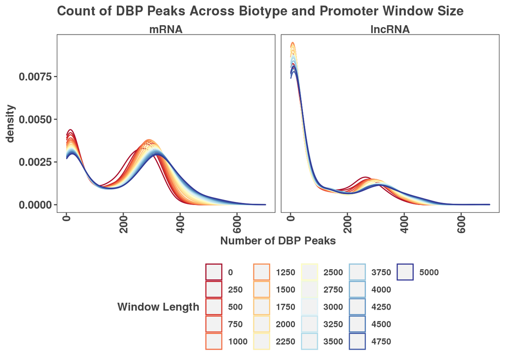

```r
# Add dummy variable to differentiate biotype
mrna_mat_dummy <- data.frame(mrna_mat_plotting, 'dummy' = rep('mRNA'))

lncrna_mat_dummy <- data.frame(lncrna_mat_plotting, 'dummy' = rep('lncRNA'))

# Mash the data together
merged_mrna_lncrna <- rbind(mrna_mat_dummy, lncrna_mat_dummy)

# Plot it pretty
ggplot(data = merged_mrna_lncrna) +
  geom_density(aes(x = value, color = as.factor(name))) +
  facet_wrap(~dummy) +
  labs(color = 'Window Length') +
  labs(title = "Count of DBP Peaks Across Biotype and Promoter Window Size") +
  theme(legend.position = 'bottom') +
  xlab("Number of DBP Peaks") +
  scale_color_manual(values = get_palette(palette = 'RdYlBu', k=length(numbers)))+
  xlim(1,700)
```

```r
ggsave('figures/peak_counts.png')
```

Next, we repeated the same figure using the “occurence” method of count_peaks_per_feature. This method only counts unique DBPs that bound inside the promoter window. Therefore, even if a DBP bound multiple times inside the window, it would only be counted once.

```r
# same procedure with "occurence"
numbers = seq(0,5000, by = 250)

# Create matrixes to store the data
mrna_mat = matrix(numeric(), ncol = 1000, nrow = length(numbers))
lncrna_mat = matrix(numeric(), ncol = 1000, nrow = length(numbers))

for (i in 1:length(numbers)){ # loop over all window sizes

   # get the regions for each biotype.
  lncrna_promoters <- get_promoter_regions(gene_samples_lncRNA, biotype = "lncRNA",
                                           upstream = numbers[i]/2, downstream = numbers[i]/2)
  mrna_promoters <- get_promoter_regions(gene_samples_mRNA, biotype = "protein_coding",
                                           upstream = numbers[i]/2, downstream = numbers[i]/2)

  # get gene names and count the number of peaks
  names(mrna_promoters) <- mrna_promoters$gene_id
  mrna_promoter_peak_counts <- count_peaks_per_feature(mrna_promoters, filtered_consensus_peaks, type = "occurrence")

  names(lncrna_promoters) <- lncrna_promoters$gene_id
  lncrna_promoter_peak_counts <- count_peaks_per_feature(lncrna_promoters, filtered_consensus_peaks, type = "occurrence")

  # save to matrix
  mrna_mat[i,] <- colSums(mrna_promoter_peak_counts)
  lncrna_mat[i,] <- colSums(lncrna_promoter_peak_counts)
}
```

We performed the same data transformation on the “occurence” data as with the “counts” data.

```r
# assign row names as window sizes
rownames(mrna_mat) <- as.character(numbers)
rownames(lncrna_mat) <- as.character(numbers)

# assign column names as genes
colnames(mrna_mat) <- mrna_promoters$gene_id
colnames(lncrna_mat) <- lncrna_promoters$gene_id
```

```r
# same operations with lncRNA data
t_mrna_mat <- as.data.frame(t(mrna_mat))

mrna_mat_plotting <- t_mrna_mat %>%
  pivot_longer(colnames(t_mrna_mat)) %>%
  as.data.frame()

mrna_mat_plotting$name <- as.numeric(mrna_mat_plotting$name)
```

```r
# same operations with lncRNA data
t_lncrna_mat <- as.data.frame(t(lncrna_mat))

lncrna_mat_plotting <- t_lncrna_mat %>%
  pivot_longer(colnames(t_lncrna_mat)) %>%
  as.data.frame()

lncrna_mat_plotting$name <- as.numeric(lncrna_mat_plotting$name)
```

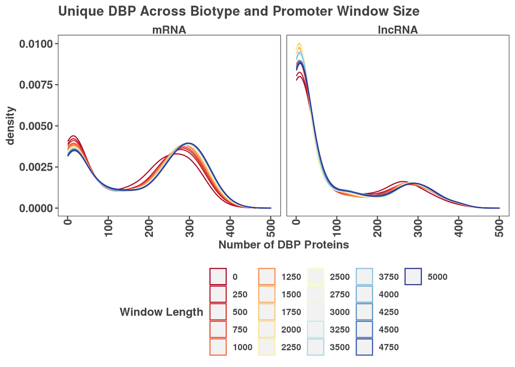

```r
# Add dummy variable to differentiate biotype
mrna_mat_dummy <- data.frame(mrna_mat_plotting, 'dummy' = rep('mRNA'))

lncrna_mat_dummy <- data.frame(lncrna_mat_plotting, 'dummy' = rep('lncRNA'))

# Mash the data together
merged_mrna_lncrna <- rbind(mrna_mat_dummy, lncrna_mat_dummy)

# Plot it pretty
ggplot(data = merged_mrna_lncrna) +
  geom_density(aes(x = value, color = as.factor(name))) +
  facet_wrap(~dummy) +
  labs(color = 'Window Length') +
  labs(title = "Unique DBP Across Biotype and Promoter Window Size") +
  theme(legend.position = 'bottom') +
  xlab("Number of DBP Proteins") +
  scale_color_manual(values = get_palette(palette = 'RdYlBu', k=length(numbers)))+
  xlim(1,500)
```

```r
ggsave('figures/peak_occurences.png')
```

We see that the bimodal distribution conserves its character from the “counts” plot to the “occurrence” plot. This could indicate that proteins that have high binding have also a diverse number of proteins binding. We see the same pattern for increasing window size, where increasing window size makes the tail of the distribution heavier.

Our data indicates that the window size does not affect the character of the bimodal distribution of DNA binding proteins. This suggests that there are two classes of types of promoters, one where very few proteins bind and one where many proteins bind. Between biotypes, we see that there are many more promoters with high number of DNA binding proteins in the mRNA promoters than the lncRNA promoters. With the lncRNA promoters, there are many promoters with very few DNA binding proteins and few with lots of DNA binding proteins.

It is important to note that all the ChIP data used in this analysis are from HEPG2, an immortalized liver cancer cell line. This is atypical cell line with mutations and abnormal chromosome number. It would be interesting to see if these result held across immortalized cell lines and healthy cell lines.

In general, it would be interesting to explore what characterizes promoters that constitute these two distinct peaks. A future direction of this research would be to look at promoter motifs and to determine if there are conserved nucleotides corresponding to the promoters that are represented by the two different peaks. Looking at this pattern across biotypes may reveal a pattern where conserved nucleotides that correspond to the second peak appear in both biotypes. Another possible direction this research could take would be to look at the types of DBPs that are binding at each of these peaks and see if there are proteins that are characteristic of one of these two promoter categories.

Looking at RNAseq transcription levels at each of these promoters may give additional insight into what differentiates these two different classes of promoters. This could evidence the idea that having more DBPs bind to a promoter allows for more (or less) transcription to take place. A final interesting direction to take this research would be to perform this same analysis with cells that had been grown in different conditions in order to determine whether the set of genes that have high expression are conserved.

Determining why there is such a distinctive peak of 200-300 proteins of which many promoters would be essential to understanding how DBPs are promoting or inhibiting expression of certain genes. Comparing similar expression levels across the two peaks would provide insight into what kinds of DBPs and promoter motifs preferentially increase expression.

We found that there are two distinct categories of promoters in terms of DBP affinity. One set of promoters has low affinity, and another has high affinity. The distinctiveness of this bimodal distribution is conserved across promoter window size and biotype. In conclusion, there are many directions that this research could be taken in. This includes characterizing the two distinct categories of promoters and looking at how expression changes between these two different categories.